# Exploring the BRFSS data

## Setup

### Load packages

```r
library(ggplot2)
library(dplyr)
```

### Load data

```r
load("brfss2013.RData")
dim(brfss2013)
```

```
## [1] 491775    330
```

## Part 1: Data

The Behavioral Risk Factor Surveillance System (BRFSS) is a survey system which collects information from various states in US to measure to measure behavioral risk factors for the non-institutionalized adult population (18 years of age and older).The survey is carried either by landline telephonic interviews or through cellular phone interviews.In conducting telephone based interview, the data is collected by randomly selecting an adult from a household while in cellular phone interview data is collected from an adult who has a cellular phone and lives either in private residence or college housing.

Thus data collected from both landline telephonic interview and celluar phone interview are case of simple random sampling since each individual is equally likely to be selected from the population.Also the sample is representative of population since the data is collected from 4,91,775 observations which are large enough to represent the sample.

Hence data collected in this system is part of observational study instead of experimental which randomly assign subjects to treatment to estabilish causal connections between explanatory and response variable.And since it is observational study, data colleted from obsevations can be analysed to see if there is any kind of correlation between explanatory and response variable.Correlation does not imply caustaion and so we conclude that the results are generalizable.

## Part 2: Research questions

**Research quesion 1:** Is there any kind of correlation between health of an individual and whether he/she performs exercise or not.Since exercise usually help a person to remain fit we are interested in checking whether an individual who exercises regulary tends to have a better health condition than the individual who doesn’t.

In this case: 1) Response vaiable is from section 1:

**genhlth - General Health**

2)Explanatory variables is from section 12:

**exerany2 - Exercise In Past 30 Days**

It implies that during the past month, other than your regular job, did you participate in any physical activities or exercises such as running, calisthenics, golf, gardening, or walking for exercise?

**Research quesion 2:**

Is poor health of an individual related to health care access.Since people who do regular health check up are more likely to be in healthy condition.Also do people having access to mutiple health care professionals have a better health than others.

To evaluate this relationship we have to consider following variables

1)Response variable is from section 2:

**menthlth -Number of days mental health not good**

It implies that for how many days during the past 30 days was your mental health not good?

2)Explanotary variable is from section 3 :

**persdoc2 - Multiple Health Care Professionals**

Do you have one person you think of as your personal doctor or health care provider? (If “No” ask “Is there more than one or is there no person who you think of as your personal doctor or health care provider?”.)

**checkup1 - Length Of Time Since Last Routine Checkup**

About how long has it been since you last visited a doctor for a routine checkup? [A routine checkup is a general physical exam, not an exam for a specific injury, illness, or condition.]

**Research quesion 3:** Is high blood pressure of individual related to smoking and drinking habbits of the individual since person who smokes and drink alcohol frequently are more often inclined in experiencing high blood pressure.

To evaluate this relationship we have to consider following variables:

1. Response vaiable is from section 5:

**bphigh4: Ever Told Blood Pressure High**

Have you ever been told by a doctor, nurse or other health professional that you have high blood pressure?

2)Explanatory variable is from section 9 & 10:

**smokday2: Frequency Of Days Now Smoking**

Do you now smoke cigarettes every day, some days, or not at all?

**avedrnk2: Avg Alcoholic Drinks Per Day In Past 30**

During the past 30 days,about how many drinks did you drink on the average?

## Part 3: Exploratory data analysis

**Research quesion 1:**

```r
# A new dataframe for required model
newdata<- names(brfss2013) %in% c("genhlth", "exerany2")
data1 <- brfss2013[newdata]

# removing rows containing blank and NAs
data1 <- na.omit(data1)
dim(data1)
```

```
## [1] 455950      2
```

```r
summary(data1)
```

```
##       genhlth       exerany2
##  Excellent: 79367   Yes:331389
##  Very good:149455   No :124561
##  Good     :139538
##  Fair     : 61793
##  Poor     : 25797
```

```r
tab_1=table(data1$exerany2, data1$genhlth)
tab_1
```

```
##
##       Excellent Very good   Good   Fair   Poor
##   Yes     67914    120595  97095  34844  10941
##   No      11453     28860  42443  26949  14856
```

we can also interpret this results from the graph displayed below

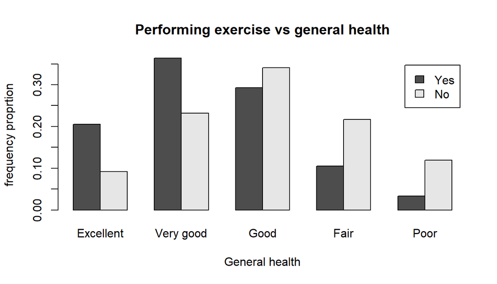

```r
barplot(prop.table(tab_1,1),beside=T,legend=T,ylab="frequency proprtion",xlab="General health",main="Performing exercise vs general health")
```

**Research quesion 2:**

```r
newdata1<- names(brfss2013) %in% c("menthlth", "persdoc2", "checkup1")
data2 <- brfss2013[newdata1]


# removing rows containing blank and NAs
data2 <- na.omit(data2)
dim(data2)
```

```
## [1] 475788      3
```

```r
summary(data2)
```

```
##     menthlth               persdoc2                     checkup1
##  Min.   : 0.000   Yes, only one:359492   Within past year   :349035
##  1st Qu.: 0.000   More than one: 39757   Within past 2 years: 56300
##  Median : 0.000   No           : 76539   Within past 5 years: 33053
##  Mean   : 3.357                          5 or more years ago: 33035
##  3rd Qu.: 2.000                          Never              :  4365
##  Max.   :30.000
```

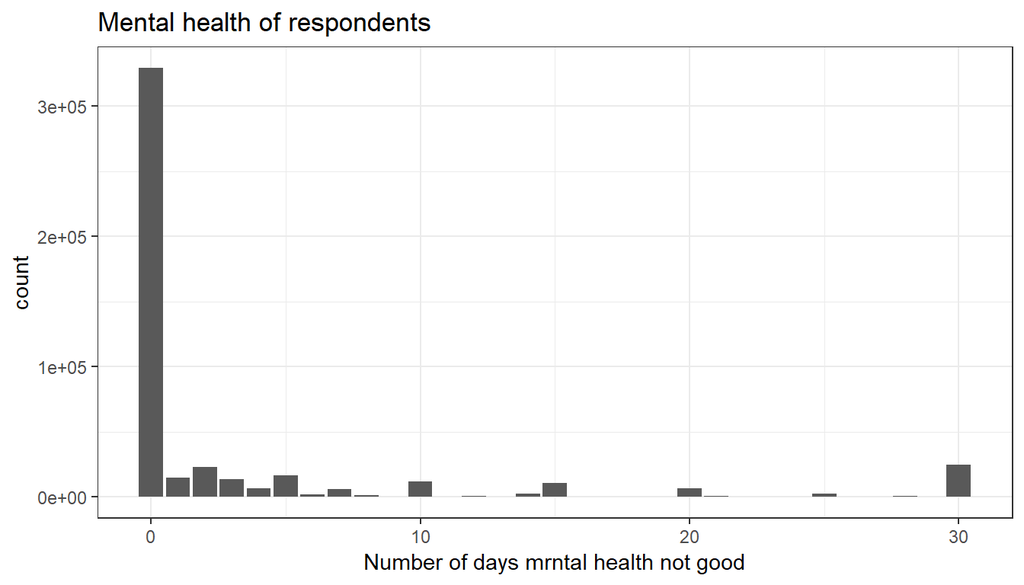

```r
attach(data2)
ggplot(data2, aes(x=menthlth)) + geom_bar() + ggtitle('Mental health of respondents') + xlab('Number of days mrntal health not good') + theme_bw()
```

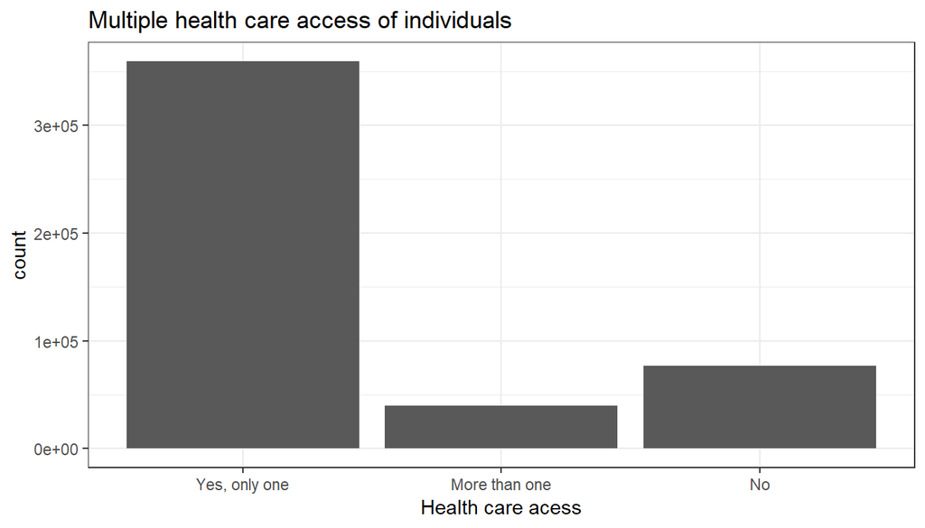

```r
ggplot(data2, aes(x=persdoc2)) + geom_bar() + ggtitle('Multiple health care access of individuals') + xlab('Health care acess') + theme_bw()
```

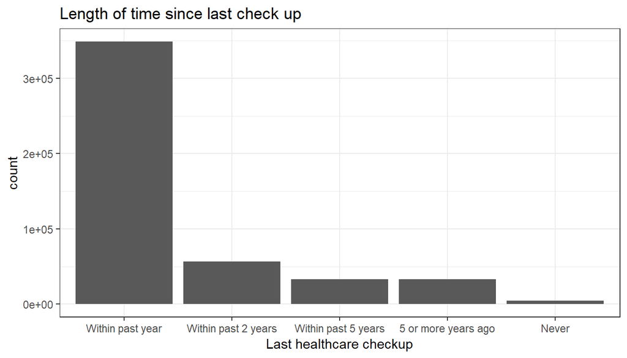

```r
ggplot(data2, aes(x=checkup1)) + geom_bar() + ggtitle('Length of time since last check up') + xlab('Last healthcare checkup') + theme_bw()
```

Followng three conclusions can be drawn from the three plots generated:

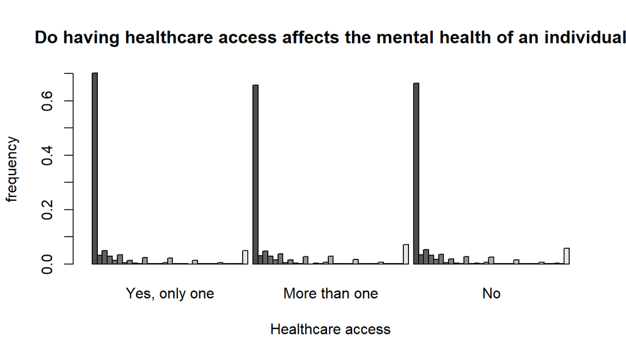

```r
barplot(prop.table(table(menthlth,persdoc2),2),beside=T,ylab="frequency",xlab="Healthcare access",main="Do having healthcare access affects the mental health of an individual")
```

We can see from the graph that having access to healthcare professionals does not affect the mental health of an individual since for all the three levels of health care access, frequency of having poor mental health is same for each day in a month i.e maximum proportion of people getting who experienced poor mental health are zero in all the three categories.

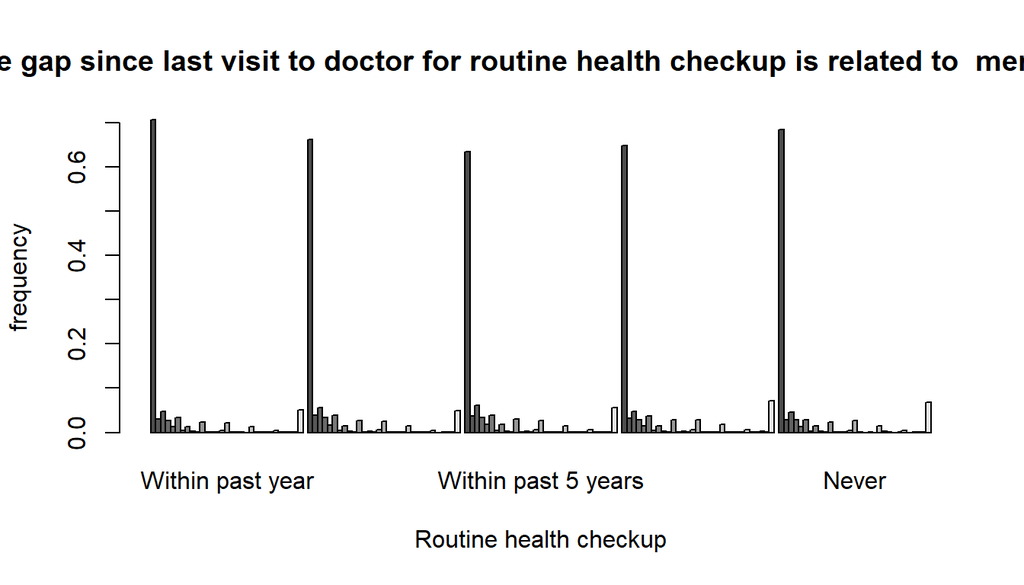

```r
barplot(prop.table(table(menthlth, checkup1),2),beside=T,ylab="frequency",xlab="Routine health checkup",main="Is time gap since last visit to doctor for routine health checkup is related to  mental health")
```

All the five categories represent almost similar trend in graph for 30 days so whether an individual had last check up within last 1 year, within last 2 year, within last 5 year,5 or more years earlier or never had one, the the number of days of poor mental health is approximately same for all the five categories.

**Research quesion 3:**

```r
# A new dataframe for required model
newdata3<- names(brfss2013) %in% c("bphigh4", "avedrnk2", "smokday2" )
data3 <- brfss2013[newdata3]

# removing rows containing blank and NAs
data3 <- na.omit(data3)
dim(data3)
```

```
## [1] 112398      3
```

```r
summary(data3)
```

```
##                                        bphigh4            smokday2
##  Yes                                       :45085   Every day :27550
##  Yes, but female told only during pregnancy:  689   Some days :11768
##  No                                        :65354   Not at all:73080
##  Told borderline or pre-hypertensive       : 1270
##
##
##     avedrnk2
##  Min.   : 1.000
##  1st Qu.: 1.000
##  Median : 2.000
##  Mean   : 2.492
##  3rd Qu.: 3.000
##  Max.   :76.000
```

Thus we have filtered our dataset which consist of three variables.To better interpret the results above let us make use of graphs.

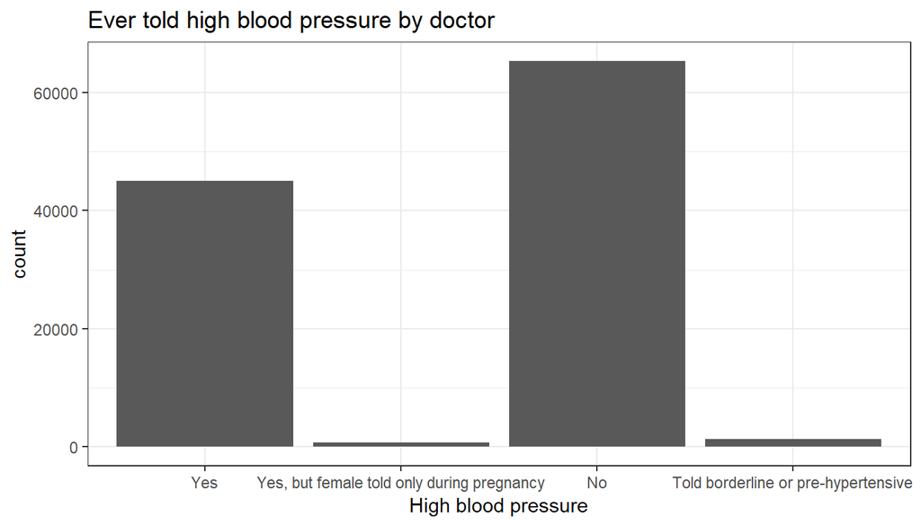

```r
ggplot(data3, aes(x=bphigh4)) + geom_bar() + ggtitle('Ever told high blood pressure by doctor') + xlab('High blood pressure') + theme_bw()
```

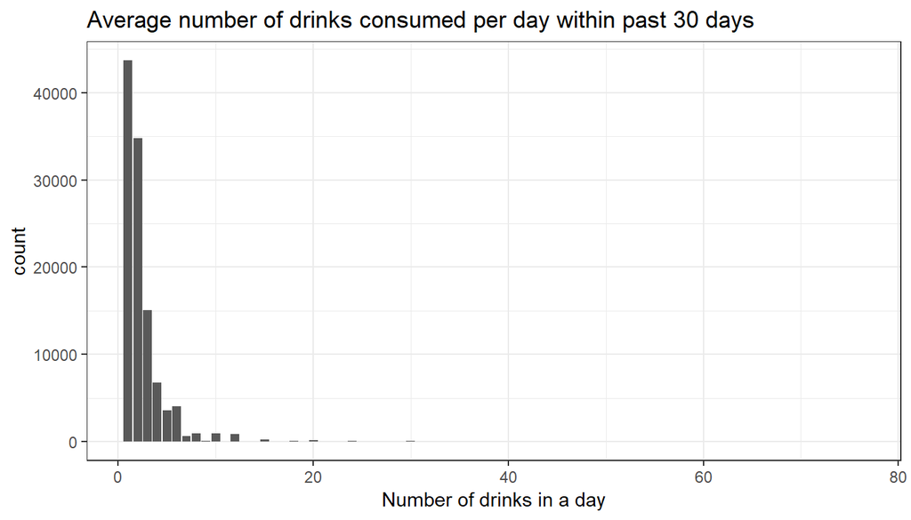

```r
 ggplot(data3, aes(x=avedrnk2)) + geom_bar() + ggtitle('Average number of drinks consumed per day within past 30 days') + xlab('Number of drinks in a day') + theme_bw()
```

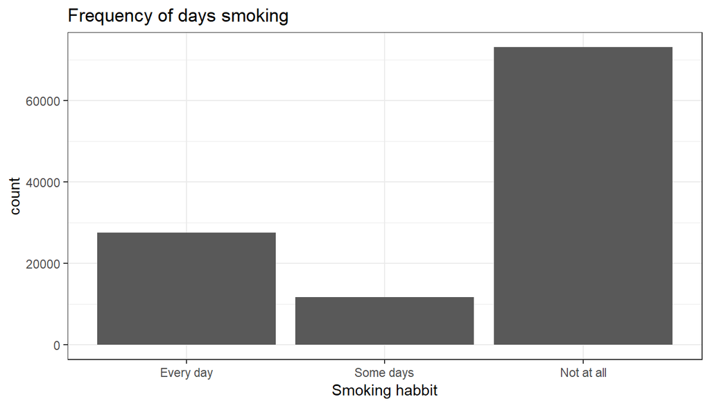

```r
ggplot(data3, aes(x=smokday2)) + geom_bar() + ggtitle('Frequency of days smoking') + xlab('Smoking habbit') + theme_bw()
```

We can draw following three conclusions from the graph

1. More proportion of respondents have been told by the doctor that they did’nt have high blood pressure.
2. Average number of drinks consumed per day by respondent in past 30 days is usually 1 or 2 by most of the respondents.Some also drank more than two per day.
3. A large proportion of people do not smoke at all followed by people who smoke regularly and least proportion of respondents smoked few of the days.

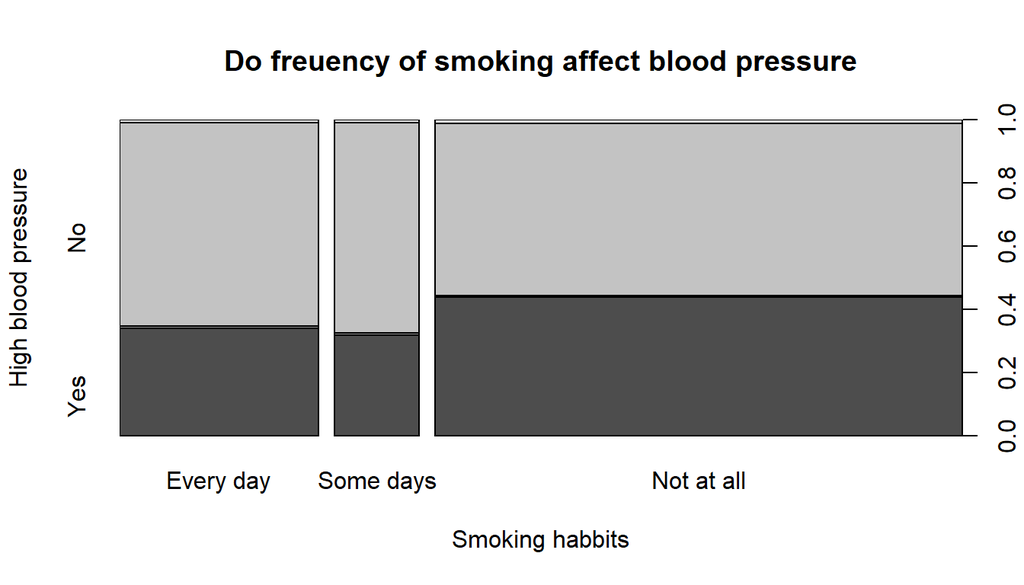

```r
bdprs=data3 %>%
  filter(!is.na(bphigh4), !is.na(avedrnk2),!is.na(smokday2)) %>%
  select(bphigh4,avedrnk2,smokday2)

plot(bdprs$smokday2,bdprs$bphigh4,xlab="Smoking habbits", ylab="High blood pressure", main="Do freuency of smoking affect blood pressure")
```

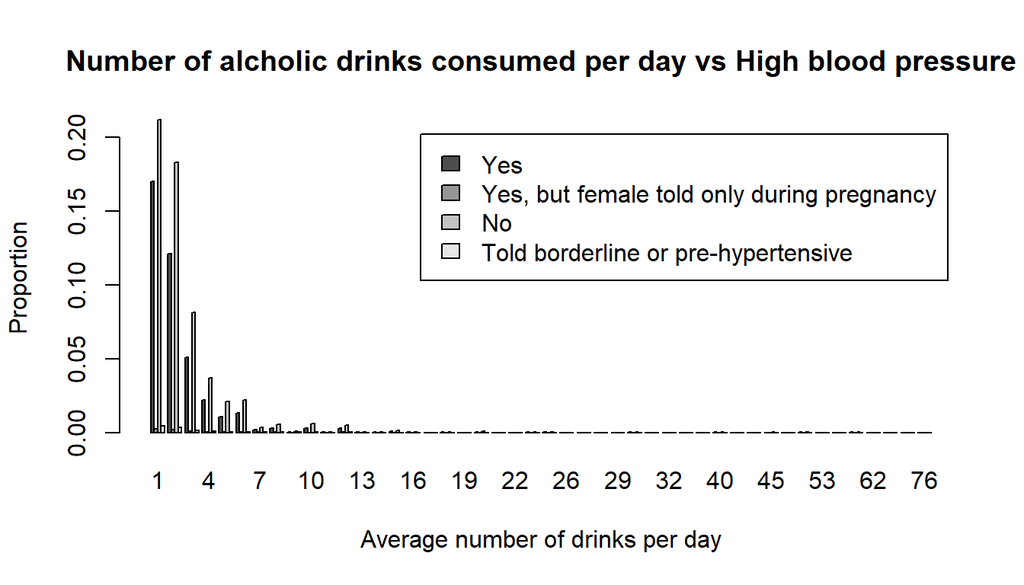

```r
barplot(prop.table(table(bdprs$bphigh4,bdprs$avedrnk2)),beside=T,legend=T,xlab="Average number of drinks per day",ylab="Proportion", main="Number of alcholic drinks consumed per day vs High blood pressure")
```